# Discordant Rogue Chinook

```r
require(adegenet)
require(knitr)
require(tidyverse)
require(magrittr)
```

# Readme

This is document is an R notebook. If you’d like view to pre-rendered figures, read a summary of analysis and interact with code, please open the relevant html file in a browser.

To conduct a similar analyses on your computer, edit or run code: clone this repository into a directory on your local machine and open the .Rproj file in Rstudio.

# Rationale

This is the analysis log for the Rogue Discordant Chinook Project. The goals are (1) confirm genotypes of two GREB1L/ROCK1 SNPs genotyped with qPCR and found to be discordant (i.e. not in perfect LD) in spring run Chinook salmon sampled throughout the Rogue River in 2018 and (2) create a spreadsheet of genotypes at GREB1L/ROCK1 markers to visually examine patterns of linkage and genomic variation in the GREB1L region of in these samples. I also added spring run Chinook salmon sampled from the lower river in 2020 and quickly made some LD plots so we wouldn’t have to rely on eyeballing it.

# Data Summary

## Before Filtering

Details on sequencing data, unfiltered genotypes and metadata available in genotyping notebook.

**Metadata**

```r
OtsAC18_run022 <- readxl::read_xlsx("metadata/GT-seq_GC3F-CKF-005_metadata.xlsx", sheet = 3)
OtsAC20_meta <- readxl::read_xlsx("metadata/GT-seq_GC3F-CKF-005-OtsAC20ROGR.xlsx", sheet = 1)

index_list <- read_csv("metadata/GT-seq_GC3F-CKF-005_Index.csv")
colnames(index_list) <- c("sample", "i7", "i5")
Ots_indexes <- filter(index_list, str_detect(sample, "Ots"))

#quick check that all samples with in the library have metadata
#sum(Ots_indexes$sample %in% c(OtsAC18_run022$Sample, OtsAC20_meta$`Individual Name`))
#yes all there

#lets grab the metadata for the 2018 samples from Sandra's metadata spreadsheet
OtsAC18_meta <- read_tsv("metadata/Rogue River_Cole Rivers Hatchery Broodstock_2018_Progeny.txt")
OtsAC18_meta %<>%
  right_join(OtsAC18_run022, by = c("SFGL ID"="Sample"))

#now let's clean this up
OtsAC18_meta %<>%
  select("SFGL ID", Date, "Wild/Hatchery", "...2", "Greb1L SNP1", "Greb1L SNP2", "Ots_SEXY3-1") %>%
  rename("sample"="SFGL ID", "date" = "Date", "NOR_HOR"="Wild/Hatchery", "location"="...2")

#and combine it with 2020 samples

OtsAC20_meta %<>%
  select("Individual Name", DateSampled, IndividualSampleLOCATION, Marks) %>%
  rename(sample="Individual Name", date = DateSampled, location = IndividualSampleLOCATION, NOR_HOR = Marks)

OtsAC18_meta %<>%
  mutate(date = as.Date(date, format= "%m/%d/%Y"))


meta_data <- OtsAC18_meta %>%
  bind_rows(OtsAC20_meta)

#all there?
#str_sub(index_list$sample[str_detect(index_list$sample, "Ots")], 0,17) %in% meta_data$sample
#yes all Ots samples in the index list are in the metadata spreadsheet

#clean up a little more
meta_data %<>%
  filter(if_any(everything(), ~ !is.na(.))) %>%
  mutate(NOR_HOR = case_when(NOR_HOR == "Unmarked" ~ "NOR",
                             NOR_HOR == "Mix" ~ "NA",
                             NOR_HOR == "Hatchery" ~ "HOR",
                             TRUE ~ NOR_HOR)) %>%
  mutate(repeat_sample = case_when(is.na(`Greb1L SNP1`) ~ "new",
                                   TRUE ~ "prev_genotyped")) %>%
  mutate(NOR_HOR = na_if(NOR_HOR, "NA"))


kable(meta_data %>%
        group_by(repeat_sample) %>%
  summarise(n = n()) )
```

| repeat_sample | n |
| --- | --- |
| new | 211 |
| prev_genotyped | 89 |

```r
kable(meta_data %>%
        ungroup()%>%
  group_by(repeat_sample, NOR_HOR, location) %>%
  summarise(n = n()) )
```

| repeat_sample | NOR_HOR | location | n |
| --- | --- | --- | --- |
| new | NOR | 226 | 3 |
| new | NOR | Clay Banks | 3 |
| new | NOR | Cole Riffle | 3 |
| new | NOR | Dunk | 6 |
| new | NOR | Elephant Rock | 8 |
| new | NOR | Huntley Park | 132 |
| new | NOR | Lobster | 18 |
| new | NOR | Quosatana | 18 |
| new | NOR | Rogue Bay | 12 |
| new | NOR | Shallow Riffle | 1 |
| new | NOR | Snag Patch | 1 |
| new | NOR | Upper Rogue | 1 |
| new | NOR | Willows | 5 |
| prev_genotyped | HOR | Cole Rivers Hatchery | 1 |
| prev_genotyped | NA | Cole Rivers Hatchery | 79 |
| prev_genotyped | NA | Lower Rogue River | 9 |

```r
rm(index_list)
rm(Ots_indexes)
rm(OtsAC18_meta)
rm(OtsAC18_run022)
rm(OtsAC20_meta)

#when picking back up fix the year issue here (previously genotyped samples from 2019 and 2020 don't have year, plus the thing we're interested in isnt year, it's genotype status (previously genotyped at TASHA SNPs or not))
```

There are 300 individuals overall, including 89 indviduals that were previously genotyped at two GREB1L SNPs and observed to be “discordant” sampled in 2018-2020, and 211 new individuals sampled in 2020. All new individuals are NOR, previously genotyped samples are almost all unknown origin (jar of fin clips with both NOR and HOR mixed).

Previously genotyped individuals were primarily sampled at Cole Rivers Hatchery from May 23rth to August 29th. Some individuals were sampled in the lower Rogue.

Sampling locations for new individuals are throughout the lower Rogue (Bay, Huntley Park - river mile 8, Quotsana Creek - river mile 14, Lobster Creek river mile 43, Port- ?, Mill site - ?) and sampling dates span from April 12th to October 7th, inclusive of both spring and fall runs.

## Final Dataset

```r
load("genotype_data/genind_2.0.R")
load("genotype_data/genotypes_2.2.R")

kable(genos_2.2 %>%
        group_by(repeat_sample) %>%
  summarise(n = n()) )
```

| repeat_sample | n |
| --- | --- |
| new | 209 |
| prev_genotyped | 87 |

```r
kable(genos_2.2 %>%
        ungroup()%>%
  group_by(repeat_sample, NOR_HOR, location) %>%
  summarise(n = n()) )
```

| repeat_sample | NOR_HOR | location | n |
| --- | --- | --- | --- |
| new | NOR | 226 | 3 |
| new | NOR | Clay Banks | 3 |
| new | NOR | Cole Riffle | 3 |
| new | NOR | Dunk | 6 |
| new | NOR | Elephant Rock | 8 |
| new | NOR | Huntley Park | 132 |
| new | NOR | Lobster | 18 |
| new | NOR | Quosatana | 18 |
| new | NOR | Rogue Bay | 10 |
| new | NOR | Shallow Riffle | 1 |
| new | NOR | Snag Patch | 1 |
| new | NOR | Upper Rogue | 1 |
| new | NOR | Willows | 5 |
| prev_genotyped | HOR | Cole Rivers Hatchery | 1 |
| prev_genotyped | NA | Cole Rivers Hatchery | 77 |
| prev_genotyped | NA | Lower Rogue River | 9 |

# qPCR-GTseq Concordance

87 individuals in the final dataset were previously genotyped at two SNPs using qPCR.

**SNP 1:**  
GTseq Panel name: Ots37124_12277401  
SWFSC name: RA4.T−12277551 / NC_037124.1:12277401-12277701 / Tasha-SNP-1  
Postion on GCA_002872995.1 Chr 28: 12277551  
Early Allele: T (inferred from Sandra’s run timing summary and “Tasha controls”) Late Allele: A

**SNP 2:**  
GTseq Panel name: Ots37124_12310649  
SWFSC name: RA7.T−12310799 NC_037124.1:12310649-12310949_Tasha-SNP-2  
Position on GCA_002872995.1 Chr 28: 12310799  
Early Allele: A (inferred from Sandra’s run timing summary and “Tasha controls”) Late Allele: T

```r
# are the genotype calls always concordant

kable(genos_2.2 %>%
  filter(repeat_sample == "prev_genotyped") %>%
  select(`Greb1L SNP1`, `Ots37124-12277401`) %>%
  mutate(SNP1_translate = case_when(tolower(`Greb1L SNP1`) == "heterozygous" ~ "TA",
                                    tolower(`Greb1L SNP1`) == "homozygous spring" ~ "TT",
                                    tolower(`Greb1L SNP1`) == "homozygous fall" ~ "AA")) %>%
  mutate(SNP1_agree = (`Ots37124-12277401`  == SNP1_translate)) %>%
  group_by(SNP1_agree) %>%
  summarise(n=n()), caption = 'Tasha SNP1 vs Ots37124_12277401 Agreement')
```

Tasha SNP1 vs Ots37124_12277401 Agreement

| SNP1_agree | n |
| --- | --- |
| FALSE | 1 |
| TRUE | 86 |

```r
kable(genos_2.2 %>%
  filter(repeat_sample == "prev_genotyped") %>%
  select(`Greb1L SNP2`, `Ots37124-12310649`) %>%
  mutate(SNP2_translate = case_when(tolower(`Greb1L SNP2`) == "heterozygous" ~ "AT",
                                    tolower(`Greb1L SNP2`) == "homozygous spring" ~ "AA",
                                    tolower(`Greb1L SNP2`) == "homozygous fall" ~ "TT")) %>%
  mutate(SNP2_agree = (`Ots37124-12310649`  == SNP2_translate)) %>%
  group_by(SNP2_agree) %>%
  summarise(n=n()), caption = 'Tasha SNP2 vs Ots37124-12310649 Agreement')
```

Tasha SNP2 vs Ots37124-12310649 Agreement

| SNP2_agree | n |
| --- | --- |
| FALSE | 1 |
| TRUE | 86 |

99% agreement (86 of 87) for both SNP1 and SNP2. Interestingly, the same individual (OtsAC20CORH_0043) was the sole disagreement at either SNP.

# GREB1L Region LD

Let’s examine the pattern of LD in the Ots28 migration-timing region.

First, we’ll create a dataset for previously genotyped samples with discordant genotypes

```r
prev_genotyped <- genos_2.2 %>%
  filter(repeat_sample == "prev_genotyped") %>%
  pull(sample)

prev_geno_genind <- genind_2.0[which(indNames(genind_2.0) %in% prev_genotyped),]

invisible(ldreport_disc_samples <- dartR::gl.report.ld(dartR::gi2gl(prev_geno_genind, verbose = 0), name = NULL, save = FALSE, nchunks = 2, ncores = 3, chunkname = NULL, verbose = 0))
```

```
##   Processing a SNP dataset
## Start conversion....
## Please note conversion of bigger data sets will take some time!
## Once finished, we recommend to save the object using >save(object, file="object.rdata")
```

```r
#now we need to add loci names back to this report
name_key <- data.frame(names(prev_geno_genind$loc.n.all), c(1:329))
colnames(name_key) <- c("marker", "id")

ldreport_disc_samples %<>%
  left_join(name_key, by = c("loc1"="id")) %>%
  rename(marker_1 = marker) %>%
  left_join(name_key, by = c("loc2"="id")) %>%
  rename(marker_2 = marker)

#now get Ots28 marker info
ots28_info <- readxl::read_xlsx("metadata/Ots28_marker_info.xlsx", sheet = 2)
ots28_info %<>%
  mutate(`Marker Name` = str_replace(`Marker Name`, "37124_", "37124-"))

ldreport28_disc_samples <- ldreport_disc_samples %>%
  filter(marker_1 %in% ots28_info$`Marker Name`) %>%
  filter(marker_2 %in% ots28_info$`Marker Name`) %>%
  left_join(select(ots28_info, `Marker Name`, Position), by = c("marker_1" = "Marker Name")) %>%
  rename(marker1_position = Position) %>%
  left_join(select(ots28_info, `Marker Name`, Position), by = c("marker_2" = "Marker Name")) %>%
  rename(marker2_position = Position) %>%
  mutate(marker_1 = fct_reorder(marker_1, marker1_position)) %>%
  mutate(marker_2 = fct_reorder(marker_2, marker2_position))

# 37124 markers are on the wrong side of the diagonal, let's print both sides
ldreport28_disc_samples_rev <- ldreport28_disc_samples
ldreport28_disc_samples_rev[, c("marker_1", "marker_2", "marker1_position", "marker2_position")] <- ldreport28_disc_samples_rev[, c("marker_2", "marker_1", "marker2_position", "marker1_position")]

ldreport28_disc_samples <- rbind(ldreport28_disc_samples, ldreport28_disc_samples_rev)


ldreport28_disc_samples %<>%
  mutate(marker_1 = fct_reorder(marker_1, marker1_position)) %>%
  mutate(marker_2 = fct_reorder(marker_2, marker2_position))
```

Then the same for new samples with genotypes that better reflect the population at large.

```r
new_samples <- genos_2.2 %>%
  filter(repeat_sample == "new") %>%
  pull(sample)

new_genind <- genind_2.0[which(indNames(genind_2.0) %in% new_samples),]

invisible(ldreport_new_samples <- dartR::gl.report.ld(dartR::gi2gl(new_genind, verbose = 0), name = NULL, save = FALSE, nchunks = 2, ncores = 3, chunkname = NULL, verbose = 0))
```

```
##   Processing a SNP dataset
## Start conversion....
## Please note conversion of bigger data sets will take some time!
## Once finished, we recommend to save the object using >save(object, file="object.rdata")
```

```r
#now we need to add loci names back to this report
name_key <- data.frame(names(new_genind$loc.n.all), c(1:329))
colnames(name_key) <- c("marker", "id")

ldreport_new_samples %<>%
  left_join(name_key, by = c("loc1"="id")) %>%
  rename(marker_1 = marker) %>%
  left_join(name_key, by = c("loc2"="id")) %>%
  rename(marker_2 = marker)

#now get Ots28 marker info
ldreport28_new_samples <- ldreport_new_samples %>%
  filter(marker_1 %in% ots28_info$`Marker Name`) %>%
  filter(marker_2 %in% ots28_info$`Marker Name`) %>%
  left_join(select(ots28_info, `Marker Name`, Position), by = c("marker_1" = "Marker Name")) %>%
  rename(marker1_position = Position) %>%
  left_join(select(ots28_info, `Marker Name`, Position), by = c("marker_2" = "Marker Name")) %>%
  rename(marker2_position = Position) %>%
  mutate(marker_1 = fct_reorder(marker_1, marker1_position)) %>%
  mutate(marker_2 = fct_reorder(marker_2, marker2_position))


# 37124 markers are on the wrong side of the diagonal, let's print both sides
ldreport28_new_samples_rev <- ldreport28_new_samples
ldreport28_new_samples_rev[, c("marker_1", "marker_2", "marker1_position", "marker2_position")] <- ldreport28_new_samples_rev[, c("marker_2", "marker_1", "marker2_position", "marker1_position")]

ldreport28_new_samples <- rbind(ldreport28_new_samples, ldreport28_new_samples_rev)


ldreport28_new_samples %<>%
  mutate(marker_1 = fct_reorder(marker_1, marker1_position)) %>%
  mutate(marker_2 = fct_reorder(marker_2, marker2_position))
```

Now, let’s examine the LD pattern at the samples with known discordance betweeen SNP1 and SNP2 (previously genotyped, discordant samples) vs the new sample that is theoretically more reflective of the actual population.

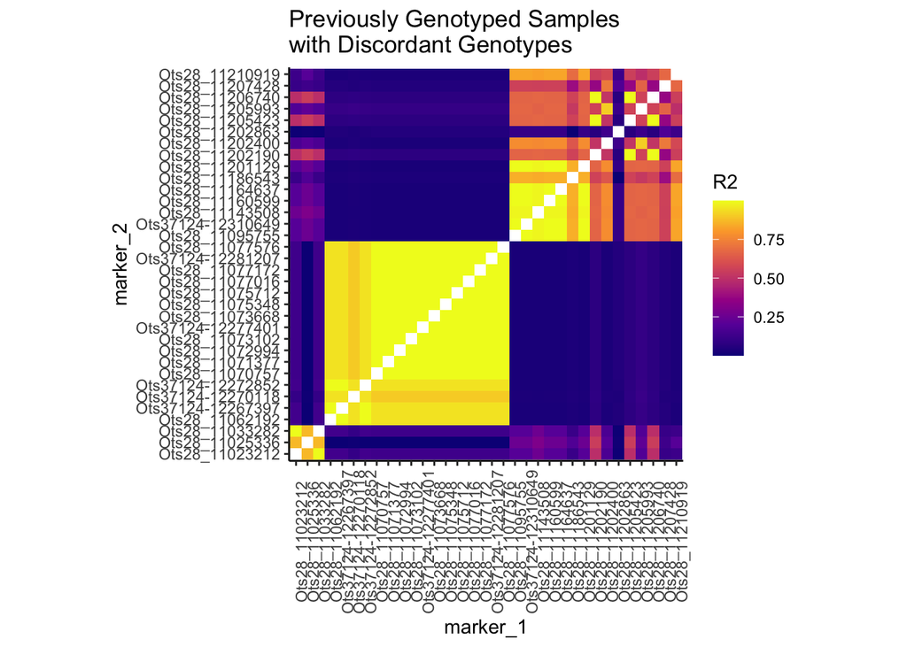

```r
ggplot(data = filter(ldreport28_disc_samples ))+geom_tile(aes(marker_1, marker_2, fill = R2), size = 2)+scale_fill_viridis_c(option = "C")+theme_classic()+theme(axis.text.x = element_text(angle = 90))+ggtitle("Previously Genotyped Samples\nwith Discordant Genotypes")+coord_equal()
```

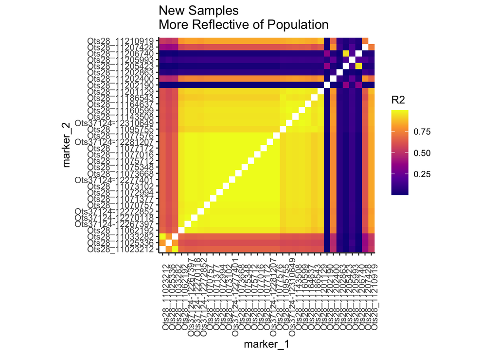

```r
ggplot(data = filter(ldreport28_new_samples ))+geom_tile(aes(marker_1, marker_2, fill = R2))+scale_fill_viridis_c(option = "C")+theme_classic()+theme(axis.text.x = element_text(angle = 90))+ggtitle("New Samples\nMore Reflective of Population")+coord_equal()
```

It appears that markers Ots28_11062912 to Ots28_11201129 are in strong linkage, when considering the new samples that are more reflective of population-wide genetic variation, but when considering the biased sample of previously genotyped individuals with discordant genotypes, the discordance seems to stem from the inheritance of two different haplotype blocks within the GREB1l region: (1) from Ots28_11062912 to Ots28_11077576, and (2) from Ots28_11095755 to Ots28_11201129.

**How common is this recombinant haplotype?**

We should be able to roughly estimate the frequency of this recombination by looking for individuals in the new samples that have discordant genotypes across the two haplotype blocks.

First, let’s look just at discordance between SNP1 and SNP2 for consistency.

```r
genos_2.2 %>%
  filter(repeat_sample == "new") %>%
  mutate(SNP1_geno_new = case_when(`Ots37124-12277401` == "TT" ~ "hom_spring",
                                   `Ots37124-12277401` == "AA" ~ "hom_fall",
                                   `Ots37124-12277401` == "TA" ~ "het")) %>%
  mutate(SNP2_geno_new = case_when(`Ots37124-12310649` == "AA" ~ "hom_spring",
                                   `Ots37124-12310649` == "TT" ~ "hom_fall",
                                   `Ots37124-12310649` == "AT" ~ "het")) %>%
  mutate(concord_gtseq = case_when(SNP1_geno_new == SNP2_geno_new ~ "concordant",
                                   TRUE ~"discordant")) %>%
  ungroup() %>%
  count(concord_gtseq)
```

|  | concord_gtseq | n |
| --- | --- | --- |
| 1 | concordant | 205 |
| 2 | discordant | 4 |

```r
  #select(sample, concord_gtseq, SNP1_geno_new, SNP2_geno_new, `Ots37124-12277401`, `Ots37124-12310649`)
```

4 of the 209 new samples have discordant genotypes at SNP1 and SNP2. This suggests the recombinant genotype occurs in about (~2%) of individuals. It will only be a rough estimation with so few samples, but, now let’s use these indivuals to see if the LD break point is similar in these individuals to our previously genotyped samples.

```r
disco_new_inds <- genos_2.2 %>%
  filter(repeat_sample == "new") %>%
  mutate(SNP1_geno_new = case_when(`Ots37124-12277401` == "TT" ~ "hom_spring",
                                   `Ots37124-12277401` == "AA" ~ "hom_fall",
                                   `Ots37124-12277401` == "TA" ~ "het")) %>%
  mutate(SNP2_geno_new = case_when(`Ots37124-12310649` == "AA" ~ "hom_spring",
                                   `Ots37124-12310649` == "TT" ~ "hom_fall",
                                   `Ots37124-12310649` == "AT" ~ "het")) %>%
  mutate(concord_gtseq = case_when(SNP1_geno_new == SNP2_geno_new ~ "concordant",
                                   TRUE ~"discordant")) %>%
  ungroup() %>%
  filter(concord_gtseq == "discordant") %>%
  pull(sample)

disco_new_genind <- genind_2.0[which(indNames(genind_2.0) %in% disco_new_inds),]

invisible(ldreport_disco_new_samples <- dartR::gl.report.ld(dartR::gi2gl(disco_new_genind, verbose = 0), name = NULL, save = FALSE, nchunks = 2, ncores = 3, chunkname = NULL, verbose = 0))
```

```
##   Processing a SNP dataset
## Start conversion....
## Please note conversion of bigger data sets will take some time!
## Once finished, we recommend to save the object using >save(object, file="object.rdata")
```

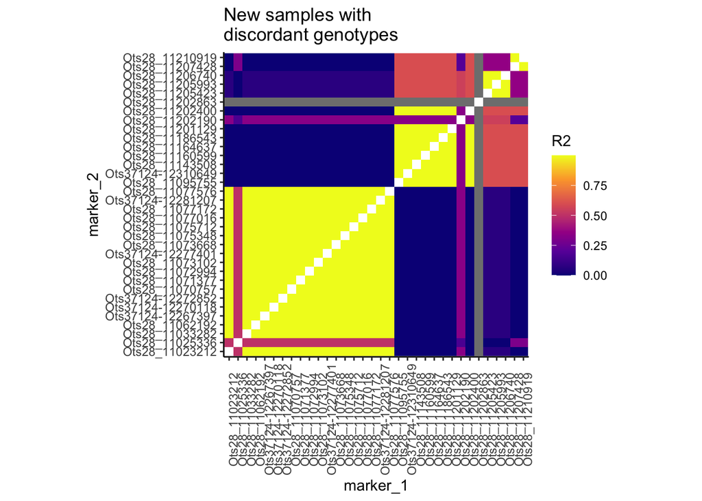

```r
#now we need to add loci names back to this report
name_key <- data.frame(names(disco_new_genind$loc.n.all), c(1:329))
colnames(name_key) <- c("marker", "id")

ldreport_disco_new_samples %<>%
  left_join(name_key, by = c("loc1"="id")) %>%
  rename(marker_1 = marker) %>%
  left_join(name_key, by = c("loc2"="id")) %>%
  rename(marker_2 = marker)

#now get Ots28 marker info

ldreport28_disco_new_samples <- ldreport_disco_new_samples %>%
  filter(marker_1 %in% ots28_info$`Marker Name`) %>%
  filter(marker_2 %in% ots28_info$`Marker Name`) %>%
  left_join(select(ots28_info, `Marker Name`, Position), by = c("marker_1" = "Marker Name")) %>%
  rename(marker1_position = Position) %>%
  left_join(select(ots28_info, `Marker Name`, Position), by = c("marker_2" = "Marker Name")) %>%
  rename(marker2_position = Position)

# 37124 markers are on the wrong side of the diagonal, let's print both sides
ldreport28_disco_new_samples_rev <- ldreport28_disco_new_samples
ldreport28_disco_new_samples_rev[, c("marker_1", "marker_2", "marker1_position", "marker2_position")] <- ldreport28_disco_new_samples_rev[, c("marker_2", "marker_1", "marker2_position", "marker1_position")]

ldreport28_disco_new_samples <- rbind(ldreport28_disco_new_samples, ldreport28_disco_new_samples_rev)


ldreport28_disco_new_samples %<>%
  mutate(marker_1 = fct_reorder(marker_1, marker1_position)) %>%
  mutate(marker_2 = fct_reorder(marker_2, marker2_position))


ggplot(data = ldreport28_disco_new_samples)+geom_tile(aes(marker_1, marker_2, fill = R2), size = 2)+scale_fill_viridis_c(option = "C")+theme_classic()+theme(axis.text.x = element_text(angle = 90))+ggtitle("New samples with\ndiscordant genotypes")+coord_equal()
```

Yep, same break point in the LD pattern.

## LD Discussion

**How does this pattern compare to previous findings?**

Understanding variation among Chinook salmon lineages in patterns of linkage disequilibrium within the GREB1L/ROCK1 genomic region is an important step towards understanding how genetic information in this region can be used to further conservation goals. In a previous study (Koch and Narum 2020), patterns of LD were found to vary among lineages of Columbia River Chinook salmon. While lower Columbia and interior ocean-type lineages possess a single haplotype block around the SNPs most strongly associated with migration timing (Koch and Narum figure 2a,b) #

[figure not shown]

.

Interior stream-type Chinook salmon have two distinct haplotype blocks in this region (Koch and Narum figure 2c). #

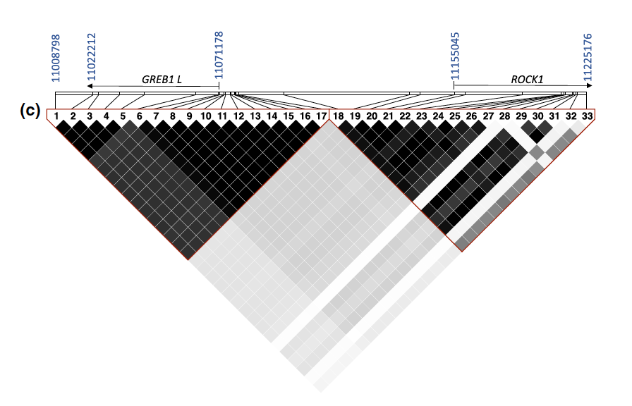

.

Interstingly, the two distinct haplotype blocks in our discordant samples have nearly the same boundaries as those found in the interior stream-type sample from Koch and Narum, although the the marker at the breakpoint in the latter study is not included in our dataset (Ots28_11078636).

*relevant Koch and Narum Figure marker id’s:*  
16: Ots28_11077576  
17: Ots28_11078636 (we don’t have this marker)  
18: Ots28_11095755

**Are “new” samples reflective of natural diversity in the Rogue Basin**

Something to keep in mind in interpreting these results, to discuss with lab.

# Genotype Table Output

It can be useful to output genotypes in an excel table to enable exploratory data analysis.

## Polarize alleles

We need a way to call (polarize) spring and fall alleles to generate an informative genotype table. In the past we’ve used alleles polarized in Columbia River populations and using a handful (1 spring, 2 fall) of samples with confirmed run timing, but given the wide sampling date range of this dataset we can probably use the data to call spring and fall allele empirically. Here, we polarize alleles as spring or fall according to the change in allele frequency over time. Please remember this polarization is solely intended as a heuristic for identifying patterns and not as an actual assertion that some alleles are “early” or “late”

First, let’s check that allele frequency at these markers changes over time. As an informal analysis, we’ll reduce dimensionality with a PCA, then look for a pattern between PC space and sample date.

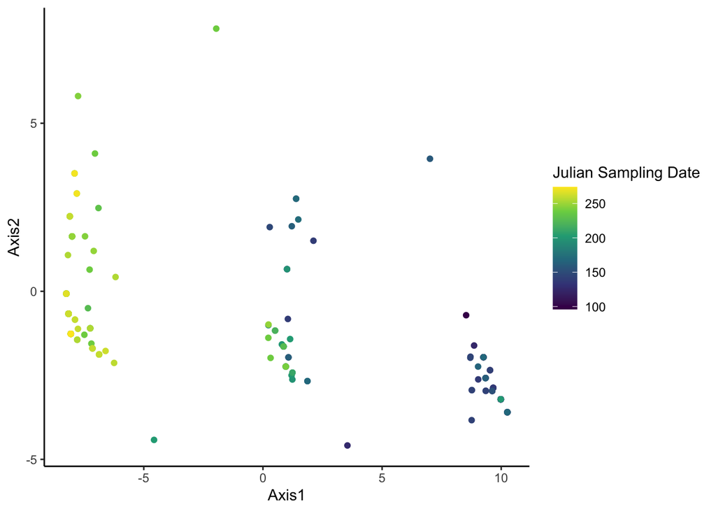

```r
run_timing_markers <- ots28_info$`Marker Name`
run_timing_markers <- str_replace(run_timing_markers, "37124_", "37124-")
genind28 <- genind_2.0[loc=run_timing_markers]

# set missing data to mean allele freq (PCA does not accomodate NAs)
X <- scaleGen(genind28,  NA.method="mean")


#then run pca, keep all PCs
pca1 <- dudi.pca(X, scale = FALSE, scannf = FALSE, nf = 68)

#kept all PCs
snp_pcs <- pca1$li#[,c(1:kg)]

#now plot data
snp_pcs %<>%
  rownames_to_column("sample") %>%
  left_join(select(genos_2.2, sample, date, repeat_sample))

snp_pcs %<>%
  mutate(jul_date = as.numeric(format(date, "%j"))) %>%
  filter(repeat_sample == "new")

ggplot(data = snp_pcs)+geom_point(aes(Axis1, Axis2, color = jul_date)) + theme_classic()+scale_color_viridis_c(name = "Julian Sampling Date")
```

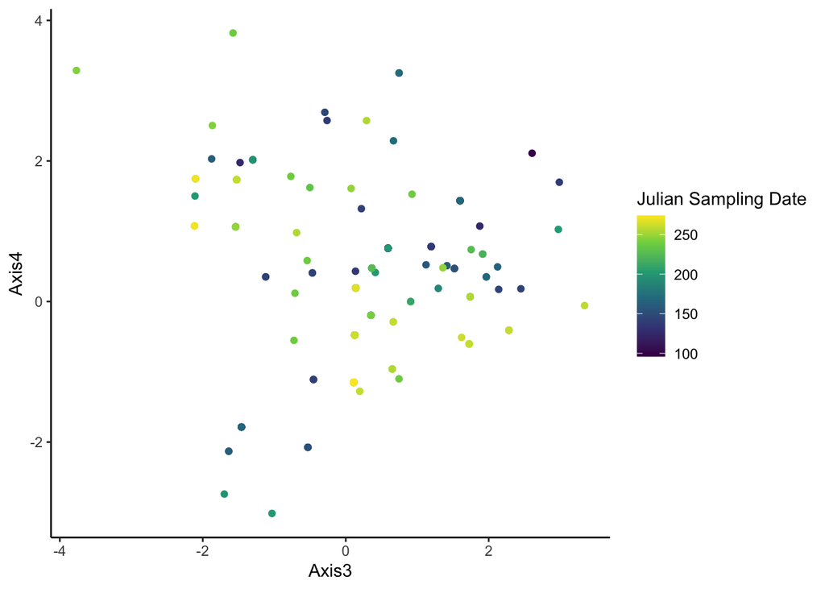

```r
ggplot(data = snp_pcs)+geom_point(aes(Axis3, Axis4, color = jul_date))  +theme_classic()+scale_color_viridis_c(name = "Julian Sampling Date")
```

Yes, there’s a strong pattern here and we are safe to polarize alleles as early or late-migrating using this dataset.

We’ll take the major allele observed in the first 50 days of samples and call that the spring allele. Note that this cutoff is somewhat arbitrary and based on the distribution of dates in the early cluster in the PCA.

```r
first_50d_samples <- genos_2.2 %>%
  filter(date < "2020-05-26" & repeat_sample == "new") %>%
  pull(sample)

genind28_early <- genind28[which(indNames(genind28) %in% first_50d_samples),]
genind28_early$pop <- as.factor(rep("rogue", 47))

# let's determine the maj and minor alleles for this dataset
early_allele_df <- as.data.frame(colSums(genind28_early$tab, na.rm = TRUE))

early_allele_df %<>%
  rownames_to_column(var = "adegent_name") %>%
  rename(count = "colSums(genind28_early$tab, na.rm = TRUE)") %>%
  mutate(marker = str_replace(adegent_name, "(.*)\\.[ATCG]", replacement = "\\1")) %>%
  mutate(allele = str_replace(adegent_name, ".*\\.([ATCG])", replacement = "\\1")) %>%
  group_by(marker) %>%
  slice_max(count) %>%
  select(marker, allele)

#oops to use this as a key for an excel spreadsheet, we would need to get the other alele too

late_allele_df <- as.data.frame(colSums(genind28_early$tab, na.rm = TRUE))

late_allele_df %<>%
  rownames_to_column(var = "adegent_name") %>%
  rename(count = "colSums(genind28_early$tab, na.rm = TRUE)") %>%
  mutate(marker = str_replace(adegent_name, "(.*)\\.[ATCG]", replacement = "\\1")) %>%
  mutate(late_allele = str_replace(adegent_name, ".*\\.([ATCG])", replacement = "\\1")) %>%
  group_by(marker) %>%
  slice_min(count) %>%
  select(marker, late_allele)

early_allele_df %<>%
  left_join(late_allele_df) %>%
  rename(early_allele = allele)

#write_tsv(early_allele_df, "empirical_run_timing_allele_key.txt")
```

## export

Now, let’s export the data

```r
# we'll grab the data from the genos_2.0 df, but order the markers according to genomic position

#fix ots28_info marker name
ots28_info2 <- ots28_info %>%
  mutate(`Marker Name` = str_replace(`Marker Name`, "37124_", "37124-")) %>%
  filter(`Marker Name` != "Ots37124-12279142")

#write_tsv(genos_2.2 %>%
  mutate(jul_date = format(date, "%j")) %>%
  select(sample, repeat_sample, date, jul_date, location, NOR_HOR, pull(ots28_info2, `Marker Name`)), "genotype_data/run_timing_geno_table.txt")
```